# Sworkit Exercise

Goal: Predict what actions are lead indicators of specific actions or workouts that might show a pattern of retaining more users.

### Variables:

- Sign-up date
- Age
- Gender
- Workouts completed (type, date, frequency)
- Current activity level (absolute beginner, beginner, intermediate, advanced)
- If they came in from any specific advertising campaign
- Plan they selected or didn't select
- General fitness goal
- If they have created and completed any custom workouts

```python
import pandas as pd
import numpy as np
from faker import Faker

# mock date
fake = Faker()
date_arr = [fake.date_between(start_date='-2y', end_date='today') for i in range(1000)]

# mock age
age_arr = np.random.randint(low=18, high=70, size=(1000))

# mock gender
gender = ['male', 'female']
gender_arr = np.random.choice(gender, size=1000)

# workouts completed
workout_arr = np.random.randint(low=0, high=90, size=(1000))

# current activity level
activity_level_arr = np.random.randint(low=0, high=10, size=(1000))

# campaign attribution
campaign = ['google_display', 'google_search', 'facebook', 'apple_store', 'google_play', 'other', 'recommendation']
campaign_arr = np.random.choice(campaign, size=1000)

# plan
plan_arr = np.random.randint(low=0, high=3, size=(1000))

# fitness goal
fitness_plan = ['leaner', 'fitter', 'stronger', 'other']
fitness_arr = np.random.choice(fitness_plan, size=1000)

# custom workouts
cw_arr = np.random.randint(low=0, high=2, size=(1000))

d = {'sign_up': date_arr,
     'age': age_arr,
     'gender': gender_arr,
     'workouts_completed': workout_arr,
     'activity_level': activity_level_arr,
     'campaign': campaign_arr,
     'plan': plan_arr,
     'fitness_goal_level': fitness_arr,
     'custom_workouts': cw_arr
    }
df = pd.DataFrame(data=d)

df.head(n=10)
```

|  | activity_level | age | campaign | custom_workouts | fitness_goal_level | gender | plan | sign_up | workouts_completed |
| --- | --- | --- | --- | --- | --- | --- | --- | --- | --- |
| 0 | 8 | 30 | google_search | 1 | fitter | male | 2 | 2017-04-11 | 69 |
| 1 | 9 | 30 | other | 1 | leaner | male | 2 | 2018-01-30 | 16 |
| 2 | 6 | 69 | apple_store | 1 | stronger | female | 1 | 2016-11-12 | 84 |
| 3 | 9 | 60 | google_display | 1 | leaner | male | 1 | 2016-07-08 | 58 |
| 4 | 3 | 31 | google_play | 1 | other | male | 1 | 2017-04-29 | 23 |
| 5 | 1 | 44 | other | 1 | other | female | 1 | 2017-01-31 | 69 |
| 6 | 9 | 51 | facebook | 1 | leaner | female | 1 | 2018-03-22 | 35 |
| 7 | 8 | 58 | google_search | 0 | other | male | 1 | 2018-03-09 | 69 |
| 8 | 6 | 35 | google_search | 0 | other | female | 0 | 2017-08-04 | 16 |
| 9 | 0 | 56 | facebook | 1 | fitter | male | 2 | 2016-08-31 | 58 |

## Mock data set

Above we can see a mock data set with some of the attributes that Sworkit collects on it's users.

### Missing information

There are a few things I'd like to note:

**Activity Level:** How is this calculated? Is it tabulated off of workouts completed or self-reported? Polynomial classification?

**Campaign:** Ideally this would be a foreign key to a table that had a lot of contextual information about the campaign -- i.e. google, bing, fb, display/search, keywords/ads associated, etc.

**Custom Workouts:** Ideally this would be a foreign key to a table that had contextual information about the custom workouts. Simply classifying the level of engagement of having a custom workout could be a binomial feature on the model, however there is probably a lot of additional information about the characteristics of a custom workout that could be used to infer more about a user's engagement.

**Plan:** 'Plan they selected or didn't select'. I'm not sure if this relates to Sworkit's 'Leaner, Fitter, Stronger' plans per your site or tier of service. I'm going to assume this is tier of service, and I'll attribute this as a set of 3, which would be foreign keys relating to free-trial, paid-standard, or paid-premium.

**Fitness Goal:** This is what I'll tabulate as Sworkit's plan offerings, as Leaner, Fitter, Stronger, or Other.

## Basic Correlation Example

The nice thing about Pandas is that is allows us to do some pretty basic pairwise correlation of columns right out of the box between two columns in this data set.

For example, let's pretend we want to examine the relationship between workouts completed and age. Is there a correlation between workouts completed and the age of a user? Below I'm going to run a Pearson correlation between the age and workouts completed columns. Since the data that was inserted was random, we *should not* see a correlation coefficient of any great signifigance.

For reference: 1 is a complete positive correlation and -1 is a complete negative correlation

```python
df['age'].corr(df['workouts_completed'], method='pearson')
```

```
0.024946478391420644
```

As expected, there was an incredibly small correlation coefficient in the random data.

Now, let's insert 2500 more rows where younger users have a higher range of workouts completed.

```python
# mock date
date_arr = [fake.date_between(start_date='-2y', end_date='today') for i in range(2500)]
# mock age
age_arr = np.random.randint(low=18, high=25, size=(2500))
# mock gender
gender_arr = np.random.choice(gender, size=2500)
# workouts completed
workout_arr = np.random.randint(low=75, high=90, size=(2500))
# current activity level
activity_level_arr = np.random.randint(low=5, high=10, size=(2500))
# campaign attribution
campaign_arr = np.random.choice(campaign, size=2500)
# plan
plan_arr = np.random.randint(low=0, high=3, size=(2500))
# fitness goal
fitness_arr = np.random.choice(fitness_plan, size=2500)
# custom workouts
cw_arr = np.random.randint(low=0, high=2, size=(2500))
d2 = {'sign_up': date_arr,
     'age': age_arr,
     'gender': gender_arr,
     'workouts_completed': workout_arr,
     'activity_level': activity_level_arr,
     'campaign': campaign_arr,
     'plan': plan_arr,
     'fitness_goal_level': fitness_arr,
     'custom_workouts': cw_arr
    }
df2 = pd.DataFrame(data=d2)
df = df.append(df2)
df.head(n=10)
```

|  | activity_level | age | campaign | custom_workouts | fitness_goal_level | gender | plan | sign_up | workouts_completed |
| --- | --- | --- | --- | --- | --- | --- | --- | --- | --- |
| 0 | 8 | 30 | google_search | 1 | fitter | male | 2 | 2017-04-11 | 69 |
| 1 | 9 | 30 | other | 1 | leaner | male | 2 | 2018-01-30 | 16 |
| 2 | 6 | 69 | apple_store | 1 | stronger | female | 1 | 2016-11-12 | 84 |
| 3 | 9 | 60 | google_display | 1 | leaner | male | 1 | 2016-07-08 | 58 |
| 4 | 3 | 31 | google_play | 1 | other | male | 1 | 2017-04-29 | 23 |
| 5 | 1 | 44 | other | 1 | other | female | 1 | 2017-01-31 | 69 |
| 6 | 9 | 51 | facebook | 1 | leaner | female | 1 | 2018-03-22 | 35 |
| 7 | 8 | 58 | google_search | 0 | other | male | 1 | 2018-03-09 | 69 |
| 8 | 6 | 35 | google_search | 0 | other | female | 0 | 2017-08-04 | 16 |
| 9 | 0 | 56 | facebook | 1 | fitter | male | 2 | 2016-08-31 | 58 |

```python
df['age'].corr(df['workouts_completed'], method='pearson')
```

```
-0.5860814580030411
```

As expected, we're seeing a fairly significant inverse correlation developing between age and workouts completed.

In order to give myself more confidence I'm going to reduce the variance in the data by grouping the age demographics and workouts completed into bins. We should see a decrease in variance.

```python
df['age_group'] = pd.cut(df['age'], bins=[-1, 18, 20, 50, 200], labels=False)
labels = np.array('1 2 3 4'.split())
df['age_group'] = labels[df['age_group']]
df['workout_group'] = pd.cut(df['workouts_completed'], bins=[-1, 10, 20, 50, 200], labels=False)
labels = np.array('1 2 3 4'.split())
df['workout_group'] = labels[df['workout_group']]
print(df.head(n=5))
df['age_group'].apply(int).corr(df['workout_group'].apply(int), method='pearson')
```

[output not shown]

```
-0.29225555736695746
```

So by subsetting our values into bins, we've decreased the amount of correlation observed between our two variables. Similarly I'll calculate correlation between the natural logs of our variables to infer a drop in correlation

```python
df['age_log'] = np.log(df['age'])
df['workouts_completed']=df.workouts_completed.mask(df.workouts_completed ==0, 1)
df['workouts_completed_log'] = np.log(df['workouts_completed'])
df['age_log'].apply(int).corr(df['workouts_completed_log'], method='pearson')
```

```
-0.32155116421997054
```

Let's visualize our correlation coefficients in a heatmap

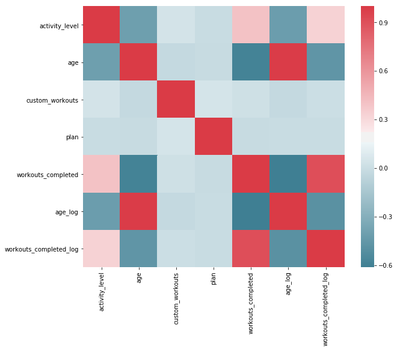

```python
import matplotlib.pyplot as plt
import seaborn as sns

f, ax = plt.subplots(figsize=(10, 8))
corr = df.corr()
sns.heatmap(corr, mask=np.zeros_like(corr, dtype=np.bool), cmap=sns.diverging_palette(220, 10, as_cmap=True),
            square=True, ax=ax)
```

Here are the pair plots between age and workouts completed

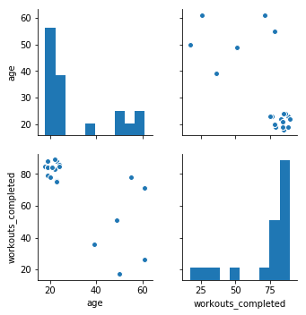

```python
df_pp = df[['age','workouts_completed']]
sns.pairplot(df_pp.sample(n=20))
```

In order to identify a pattern of retaining more users, we'll have to define some metris for what retainment entails. We'll need to understand length of account being open, and interaction with account at the least.

To define those, we'll add a deleted_account variable to our dataset, and add time range for how long the account has been open

```python
df = df.drop(columns=['age_log', 'workouts_completed_log', 'age_group', 'workout_group'])

from datetime import date, timedelta

df['deleted_account'] = df['sign_up'] + timedelta(np.random.randint(30,500))
df['deleted_account'] = df.deleted_account.mask(df.deleted_account > date.today(), 'null')

df.head(n=5)
```

[output not shown]